# Classification- Logistic Regression

### Load required data

```r
data(Stock)
```

```
data set ‘Stock’ not found
```

### Get a knowhow of Data

```r
cor(Smarket[, -9])
```

```
             Year         Lag1         Lag2         Lag3         Lag4         Lag5
Year   1.00000000  0.029699649  0.030596422  0.033194581  0.035688718  0.029787995
Lag1   0.02969965  1.000000000 -0.026294328 -0.010803402 -0.002985911 -0.005674606
Lag2   0.03059642 -0.026294328  1.000000000 -0.025896670 -0.010853533 -0.003557949
Lag3   0.03319458 -0.010803402 -0.025896670  1.000000000 -0.024051036 -0.018808338
Lag4   0.03568872 -0.002985911 -0.010853533 -0.024051036  1.000000000 -0.027083641
Lag5   0.02978799 -0.005674606 -0.003557949 -0.018808338 -0.027083641  1.000000000
Volume 0.53900647  0.040909908 -0.043383215 -0.041823686 -0.048414246 -0.022002315
Today  0.03009523 -0.026155045 -0.010250033 -0.002447647 -0.006899527 -0.034860083
            Volume        Today
Year    0.53900647  0.030095229
Lag1    0.04090991 -0.026155045
Lag2   -0.04338321 -0.010250033
Lag3   -0.04182369 -0.002447647
Lag4   -0.04841425 -0.006899527
Lag5   -0.02200231 -0.034860083
Volume  1.00000000  0.014591823
Today   0.01459182  1.000000000
```

As can be seen, also will be expected- there is a very minimal correlation between the previous day returns, but only Correlation is among the Year and Volume.

#### Let’s plot the data

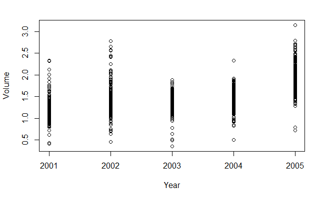

Volume has increased over time, i.e. daily trading increased in between the Years, 2001 and 2005.

### Fit a Logistic Regression

```r
summary(glm.fit)
```

```
Call:
glm(formula = Direction ~ Lag1 + Lag2 + Lag3 + Lag4 + Lag5 +
    Volume, family = binomial, data = Smarket)

Deviance Residuals:
   Min      1Q  Median      3Q     Max
-1.446  -1.203   1.065   1.145   1.326

Coefficients:
             Estimate Std. Error z value Pr(>|z|)
(Intercept) -0.126000   0.240736  -0.523    0.601
Lag1        -0.073074   0.050167  -1.457    0.145
Lag2        -0.042301   0.050086  -0.845    0.398
Lag3         0.011085   0.049939   0.222    0.824
Lag4         0.009359   0.049974   0.187    0.851
Lag5         0.010313   0.049511   0.208    0.835
Volume       0.135441   0.158360   0.855    0.392

(Dispersion parameter for binomial family taken to be 1)

    Null deviance: 1731.2  on 1249  degrees of freedom
Residual deviance: 1727.6  on 1243  degrees of freedom
AIC: 1741.6

Number of Fisher Scoring iterations: 3
```

With this model, no predictor seems to have an effective correlation with the Direction. Lag1 has the lowest p-value of all, but is still large to be used as a supporting to declare an association.

```r
summary(glm.fit)$coef[, 4]
```

```
(Intercept)        Lag1        Lag2        Lag3        Lag4        Lag5      Volume
  0.6006983   0.1452272   0.3983491   0.8243333   0.8514445   0.8349974   0.3924004
```

R uses the value as 1 for computing if the market went UP.

```r
contrasts(Direction)
```

```
     Up
Down  0
Up    1
```

#### Make a Prediction

```r
glm.probs[1:10]
```

```
        1         2         3         4         5         6         7         8         9        10
0.5070841 0.4814679 0.4811388 0.5152224 0.5107812 0.5069565 0.4926509 0.5092292 0.5176135 0.4888378
```

#### For a better inference, let’s map the probabilities to “Up” or “Down”.

```r
mean(glm.pred==Direction)
```

```
[1] 0.5216
```

But, the predictions has been calculated on the Training Data itself, and cannot be relied upon for accuracy against a Test data.

### To overcome this, let’s separate the data out into tarining and test data.

```r
Direction.2005
```

[output not shown]

#### Design a new fit.

```r
length(glm.probs)
```

```
[1] 252
```

#### But, we can at least try to re- fit the model with the predictors, most effective of all.

```r
summary(glm.fit)
```

```
Call:
glm(formula = Direction ~ Lag1 + Lag2, family = binomial, data = Smarket,
    subset = train)

Deviance Residuals:
   Min      1Q  Median      3Q     Max
-1.345  -1.188   1.074   1.164   1.326

Coefficients:
            Estimate Std. Error z value Pr(>|z|)
(Intercept)  0.03222    0.06338   0.508    0.611
Lag1        -0.05562    0.05171  -1.076    0.282
Lag2        -0.04449    0.05166  -0.861    0.389

(Dispersion parameter for binomial family taken to be 1)

    Null deviance: 1383.3  on 997  degrees of freedom
Residual deviance: 1381.4  on 995  degrees of freedom
AIC: 1387.4

Number of Fisher Scoring iterations: 3
```

```r
table(glm.pred, Direction.2005)
```

```
        Direction.2005
glm.pred Down  Up
    Down   35  35
    Up     76 106
```

Test error rate = 44%

#### test a prediction for any test inputs.

```r
predict(glm.fit, newdata= data.frame(Lag1=c(1.2, 1.5), Lag2=c(1.1, -0.8)), type="response")
```

```
        1         2
0.4791462 0.4960939
```